# Rank-normalized split-Rhat and relative efficiency estimates

Aki Vehtari, Andrew Gelman, Daniel Simpson, Bob Carpenter, Paul Bürkner

August 2018

# 1 Introduction

Split-$\widehat{R}$ and effective sample size ($N_{\rm eff}$) are routinely used to monitor the convergence of iterative simulations. $\widehat{R}$ (Gelman and Rubin, 1992; Brooks and Gelman, 1998) and *split*-$\widehat{R}$ (Gelman et al., 2013) are based on the ratio of between and within-chain marginal variances of the simulations. The effective sample size estimate by Gelman et al. (2013) is based on marginal variance and autocorrelation estimates from split chains.

$\widehat{R}$, *split*-$\widehat{R}$, and $N_{\rm eff}$ are well defined only if the marginal distributions have finite mean and variance. and even in that case, they are less stable for distributions with long tails. To alleviate these problems, we propose to compute *split*-$\widehat{R}$ and $N_{\rm eff}$ using rank normalized values, quantiles, and posterior intervals.

We additionally propose

- to diagnose convergence and relative efficiency of the marginal distribution’s scale in addition to the usual location estimate (mean or median), which will improve reliability of Monte Carlo error estimates
- to use relative efficiency of several quantile or small interval probability estimates as local relative efficiency measures to reveal local sampling problems
- to use rank plots as a more compact alternative to trace plots.

# 2 Review of *split*-$\widehat{R}$ and effective sample size

In this section, we will review split-$\widehat{R}$ and effective sample size estimates as implemented in Stan 2.18 (ref).

## 2.1 *Split*-$\widehat{R}$

Below, we present the computation of *Split*-$\widehat{R}$ following the notation of Gelman et al. (2013). For each scalar summary of interest $\psi$, we compute $B$ and $W$, the between- and within-chain variances:
$$B = \frac{n}{m-1}\sum_{j=1}^{m}(\overline{\psi}_{.j}-\overline{\psi}_{..})^2,
\;\mbox{ where }\;\;\overline{\psi}_{.j}=\frac{1}{n}\sum_{i=1}^n \psi_{ij},\;\;
\;\;\overline{\psi}_{..} = \frac{1}{m}\sum_{j=1}^m\overline{\psi}_{.j}\\
W =
\frac{1}{m}\sum_{j=1}^{m}s_j^2, \;\mbox{ where }\;\; s_j^2=\frac{1}{n-1}
\sum_{i=1}^n (\psi_{ij}-\overline{\psi}_{.j})^2.$$

In the above equations, $n$ is the number of simulations per chain and $m$ is the number of chains. The between-chain variance, $B$, also contains the factor $n$ because it is based on the variance of the within-chain means, $\overline{\psi}_{.j}$, each of which is an average of $n$ values $\psi_{ij}$.

We can estimate $\mbox{var}(\psi|y)$, the marginal posterior variance of the estimand, by a weighted average of $W$ and $B$, namely
$$\widehat{\mbox{var}}^+(\psi|y)=\frac{n-1}{n}W + \frac{1}{n}B.$$
This quantity *overestimates* the marginal posterior variance assuming the starting distribution is appropriately overdispersed compared to the target distribution, but is *unbiased* under stationarity (that is, if the starting distribution equals the target distribution), or in the limit $n\rightarrow\infty$. To have an overdispersed starting distribution, independent Markov chains should be initialized with diffuse starting values for the parameters.

Meanwhile, for any finite $n$, the within-chain variance $W$ should *underestimate* $\mbox{var}(\psi|y)$ because the individual chains haven’t had the time to explore all of the target distribution and, as a result, will have less variability. In the limit as $n\rightarrow\infty$, the expectation of $W$ approaches $\mbox{var}(\psi|y)$.

We monitor convergence of the iterative simulation to the target distribution by estimating the factor by which the scale of the current distribution for $\psi$ might be reduced if the simulations were continued in the limit $n\rightarrow\infty$. This potential scale reduction is estimated as
$$\widehat{R}=
\sqrt{\frac{\widehat{\mbox{var}}^+(\psi|y)}{W}},$$
which declines to 1 as $n\rightarrow\infty$. We call this *split*-$\widehat{R}$ because we are applying it to chains that have been split in half so that $m$ is twice the number of actual chains. Without splitting, $\widehat{R}$ would get fooled by non-stationary chains.

## 2.2 Effective sample size

If the $n$ simulation draws within each chain were truly independent, the between-chain variance $B$ would be an unbiased estimate of the posterior variance, $\mbox{var}(\psi|y)$, and we would have a total of $N = m \times n$ independent simulations from the $m$ chains. In general, however, the simulations of $\psi$ within each chain will be autocorrelated, and thus $B$ will be larger than $\mbox{var}(\psi|y)$, in expectation.

A nice introductory reference for analyzing MCMC results in general and effective sample size in particular is provided in Geyer (2011). The particular calculations used by Stan follow those for split-$\hat{R}$, which involve both between-chain (mean) and within-chain calculations (autocorrelation). They were introduced in the Stan manual and explained in more detail in Gelman et al. (2013).

One way to define effective sample size for correlated simulation draws is to consider the statistical efficiency of the average of the simulations $\bar{\psi}_{..}$ as an estimate of the posterior mean $\mbox{E}(\psi|y)$. This can be a reasonable baseline even though it is not the only possible summary and might be inappropriate, for example, if there is particular interest in accurate representation of low-probability events in the tails of the distribution.

The effective sample size of a chain is defined in terms of the autocorrelations within the chain at different lags. The autocorrelation $\rho_t$ at lag $t \geq 0$ for a chain with joint probability function $p(\theta)$ with mean $\mu$ and variance $\sigma^2$ is defined to be
$$\rho_t
=
\frac{1}{\sigma^2} \, \int_{\Theta} (\theta^{(n)} - \mu)
(\theta^{(n+t)} - \mu) \, p(\theta) \, d\theta.$$
This is just the correlation between the two chains offset by $t$ positions. Because we know $\theta^{(n)}$ and $\theta^{(n+t)}$ have the same marginal distribution in an MCMC setting, multiplying the two difference terms and reducing yields
$$\rho_t
=
\frac{1}{\sigma^2} \, \int_{\Theta} \theta^{(n)} \, \theta^{(n+t)} \, p(\theta) \, d\theta.$$

The effective sample size of $N$ samples generated by a process with autocorrelations $\rho_t$ is defined by
$$N_{\rm eff}
\ = \
\frac{N}{\sum_{t = -\infty}^{\infty} \rho_t}
\ = \
\frac{N}{1 + 2 \sum_{t = 1}^{\infty} \rho_t}.$$

Effective sample size $N_{\rm eff}$ can be larger than $N$ in case of antithetic Markov chains, which have negative autocorrelations on odd lags. Dynamic Hamiltonian algorithm used in Stan can produce $N_{\rm eff}>N$ for parameters which have close to Gaussian posterior with low dependency on other parameters (before version 2.18, Stan computed $N_{\rm eff}$ so that the maximum reported value was $N$).

In practice, the probability function in question cannot be tractably integrated and thus the autocorrelation cannot be calculated, nor the effective sample size. Instead, these quantities must be estimated from the samples themselves. The rest of this section describes am autocorrelation and split-$\hat{R}$ based effective sample size estimator, based on multiple split chains. For simplicity, each chain will be assumed to be of the same length $N$.

Stan carries out the autocorrelation computations for all lags simultaneously using Eigen’s fast Fourier transform (FFT) package with appropriate padding (see Geyer, 2011, for more details on using FFT for autocorrelation calculations). The autocorrelation estimates $\hat{\rho}_{t,j}$ at lag $t$ from chain $j\in (1,\ldots,m)$ are combined with the within-chain variance estimate $W$ and the multi-chain variance estimate $\widehat{\mbox{var}}^{+}$ introduced in the previous section to compute the combined autocorrelation at lag $t$ as
$$\hat{\rho}_t
= 1 - \frac{\displaystyle W - \textstyle \frac{1}{m}\sum_{j=1}^m \hat{\rho}_{t,j}}{\widehat{\mbox{var}}^{+}}. \label{rhohat}$$
If the chains have not converged, the variance estimator $\widehat{\mbox{var}}^{+}$ will overestimate the true marginal variance which leads to an overestimation of the autocorrelation and an underestimation of the effective sample size.

Because of the noise in the correlation estimates $\hat{\rho}_t$ as $t$ increases, typically the truncated sum of $\hat{\rho}_t$ is used. Negative autocorrelations can happen only on odd lags and by summing over pairs starting from lag 0, the paired autocorrelation is guaranteed to be positive, monotone and convex modulo estimator noise (Geyer, 1992; Geyer, 2011). Stan uses Geyer’s initial monotone sequence criterion. The effective sample size estimator is defined as
$$\hat{N}_{\rm eff} = \frac{N \, m}{\hat{\tau}},$$
where
$$\hat{\tau} = 1 + 2 \sum_{t=1}^{2k+1} \hat{\rho}_t =
-1 + 2 \sum_{t'=0}^{k} \hat{P}_{t'},$$
and $\hat{P}_{t'}=\hat{\rho}_{2t'}+\hat{\rho}_{2t'+1}$. Initial positive sequence estimators is obtained by choosing the largest $k$ such that $\hat{P}_{t'}>0, \quad t' = 1,\ldots,k$. The initial monotone sequence is obtained by further reducing $\hat{P}_{t'}$ to the minimum of the preceding ones so that the estimated sequence is monotone.

In Stan pre 2.18, slightly incorrect initial sequence was used, which had the effect that the $\hat{N}_{\rm eff}$ estimate was capped at $N$. As antithetic behavior $\hat{N}_{\rm eff} > N$ is not that common or the effect is small and capping at $N$ can be considered to be pessismistic, this had negligible effect on any inference. However, it may have led to an underestimation of Stan’s efficiency when compared to other packages performing MCMC sampling.

# 3 New *split*-$\widehat{R}$ and relative efficiency estimate

As *split*-$\widehat{R}$, and $N_{\rm eff}$ are well defined only if the marginal posteriors have finite mean and variance, we next describe approaches which are well defined for all distributions and more robust for long tailed distributions.

## 3.1 Rank normalization

Rank normalization is commonly used in Spearman’s rank correlation coefficient, but also to transform predictor values in epidemiology. Rank normalization replaces each draw by its rank (or fractional rank which the rank divided by the total number of observations). We use average rank for ties to conserve the number of values in case of discrete quantities. Rank normalization is made jointly for all draws from all chains.

Rank normalization makes the subsequent computations well defined and invariant under bijective transformations. This means that we get the same results, for example, if we use unconstrained or constrained parameters.

Furthermore, to improve sensitivity to scale differences between chains, we consider folded rank-normalization which uses rank distance from the median.

*Split*-$\widehat{R}$ can miss if chains have different scales but the same location. To alleviate this, we propose to compute *Split*-$\widehat{R}$ also for folded rank normalized values. Folded values are obtained by applying the absolute deviation transformation
$$\begin{equation}
{\rm abs}(x-{\rm median}(x)),
\end{equation}$$
where the median is computed from the draws from all chains. Folded rank normalized values are then obtained by rank normalizing the folded values.

To obtain a single conservative $\widehat{R}$ estimate, we propose to report the maximum of *rank-normalized-split*-$\widehat{R}$ and *folded-rank-normalized-split*-$\widehat{R}$ for each parameter.

## 3.2 Relative efficiency of mean rank

In addition of using rank-normalized values for convergence diagnostics, we can also compute the corresponding effective sample. This estimate will be well defined even if the original distribution does not have finite mean and variance, but it is not directly applicable to estimate the Monte Carlo error of the mean of the original values. We could transform quantiles the Monte Carlo error of the mean rank normalized value back to the original scale, but for simplicity we propose to report (bijective) transformation invariant relative efficiency values
$$R_{\rm eff}=\textit{split-rank-normalized-}N_{\rm eff} / N,$$
where $N$ is the total number of draws.

## 3.3 Relative efficiency of median and MAD

Since the marginal posterior distributions might not have finite mean and variance, by default RStan and RStanARM report median and median absolute deviation (MAD) instead of mean and standard error (SE). Median and MAD are well defined even when the marginal distribution does not have finite mean and variance.

By definition of the median, we have $p(x < {\rm median}(x)) = 0.5$. We can’t present this as a simple expectation, but we can estimate it by
$$\frac{1}{S}\sum_{s=1}^S I_{x_s<{\rm median}(x)}(x_s),$$
where $S$ is the number of draws. The indicator function transforms simulation draws to 0’s and 1’s, and thus the subsequent computations are bijectively invariant. Instead of estimating the efficiency of the median directly, we can estimate the efficiency of $p(x < \hat{Q}_{0.5})$, where $\hat{Q}_{0.5}$ is the empirical median from the combined draws. This should be good approximation, if the efficiency for $p(x < \hat{Q}_{\alpha})$ is smoothly changing around $\alpha = 0.5$. Compared to relative efficiency of the mean rank, this is a more local measue as it only assesses how the simulation jumps around the median.

We can also compute the approximative relative efficiency for the median absolute deviation (MAD), by computing the relative efficiency for median of absolute deviations from the median of all draws. The absolute deviations from the median of all draws are same as previously defined for folded samples
$${\rm abs}(x-{\rm median}(x)).$$
We see that the relative efficiency of MAD is obtained by using the same approach as for median but with the folded values also used in $\textit{split-rank-normalized-}\widehat{R}$.

Previously, Stan had reported $N_{\rm eff}$ only for the posterior location (previously mean but now median), but we demonstrate that it is good to report the relative efficiency also for an estimation of the scale (and we propose to use MAD).

## 3.4 Relative efficiency of quantiles

We can compute the relative efficiency also for other quantiles than the median. Some tail quantiles such as the 5% quantile or the 95% quantile are often used to construct credible intervals. Estimating the relative efficiency of such quantiles thus has high practical relevance in particular as we observe the relative efficiency for tail quantiles is often lower than for mean or median. By computing relative efficiency for many quantiles, we can obtain local efficiency measures as demonstrated in the experiments.

## 3.5 Relative efficiency of small interval probability estimates

We can get even more local relative efficiency estimate by considering small intervals. We propose to compute the relative efficiency for $p(\hat{Q}_\alpha \le x < \hat{Q}_{\alpha+\delta})$, where $\hat{Q}_\alpha$ is the empirical $\alpha$-quantile, $\delta=1/k$ is the length of the interval with some positive integer $k$ chosen by the researcher, and $\alpha \in (0,\delta,\ldots,1-\delta)$ changes in steps of $\delta$. Each interval has $N/k$ draws, and the efficiency measures autocorrelation of an indicator function which indicates when the values are inside the specific interval. This gives us a local efficiency measure which does not depend on the shape of the distribution. We demonstrate its usefulness as a diagnostic and educational tool to teach why expectations of different functionals may have different $N_{\rm eff}$.

## 3.6 Local efficiency for distributional approximations

We note that we can plot similar local relative efficiency plots also for distributional approximations (like Laplace and ADVI approximations), using Pareto smoothed importance sampling based effective sample size estimates (Vehtari et al, 2017). There will be another case study for this.

## 3.7 Rank plots

In additional of using rank-normalized values to compute *split*-$\widehat{R}$, we propose to use rank plots for each chain instead of traces. These can be used instead of trace plots, which in case of long chains tend to squeeze to a mess. We illustrate that rank plots can be used as a more compact alternative to trace plots.

## 3.8 Finite mean and variance of a marginal distribution

We intentionally separate MCMC diagnostics based on generic and stable rank-normalized relative efficiency $\hat{N}_{\rm eff}/N$ and Monte Carlo error estimates for desired quantities, as the latter is only applicable when mean and variance of this quantity exist. We could use Pareto-$k$-diagnostics to estimate the existance of mean and variance (Vehtari, Gabry, & Gelman, 2017), but this is out of the scope of the present case study. In the future, there will be a separate case study for diagnostics to check whether a certain marginal distribution has finite mean and variance required to obtain reasonable estimates of posterior mean and Monte-Carlo standard error.

## 3.9 Abbreviations

In the code and figures the following abbreviations have been used

- Rhat = classic no-split-Rhat
- sRhat = classic split-Rhat
- zsRhat = rank-normalized split-Rhat
  - all draws are jointly ranked, z-transformed and put back to the chains
  - can detect differences in location and trends
- fzsRhat = folded rank-normalized split-Rhat
  - all draws are jointly “folded” by computing absolute deviation from median, ranked, z-transformed and put back to the chains
  - can detect differences in scales
- neff = no-split effective sample size
- reff = neff / N
- zsneff = rank-normalized split effective sample size
  - estimates the efficiency of mean estimate for rank normalized values
- zsreff = zsneff / N
- fzsneff = folded rank-normalized split effective sample size
  - estimates the efficiency of rank normalized *mean* absolute deviation
- fzsreff = fzsneff / N
- medsneff = median split effective sample size
  - estimates the efficiency of median
  - approximated using efficiency for $p(x < \hat{Q}_{0.5})$
- medsreff = medsneff / N
- madsneff = mad split effective sample size
  - estimates the efficiency of median absolute deviation
- madsreff = madsneff / N

## 3.10 Proposed changes in Stan

The proposal is to switch in Stan

- from split-$\widehat{R}$ (sRhat) to the maximum of rank-normalized-split-$\widehat{R}$ and folded-rank-normalized-split-$\widehat{R}$: max(zsRhat, fzsRhat)
- from classic effective sample size estimate (neff), which currently doesn’t use chain splitting, to rank-normalized-split-$R_{\rm eff}$ (zsreff) and folded-rank-normalized-split-$R_{\rm eff}$ (fzsreff)
- if computing median and MAD_SD, report corresponding $R_{\rm eff}$’s (medsreff and madsreff)

Justifications for the change are

- Rank normalization makes zsRhat and zsreff well defined for all distributions, invariant under bijective transformations and more stable than sRhat and neff. Adding a folded version fzsRhat helps to detect differences in scale.
- Relative efficiencies of the median and MAD (medsreff and masreff) are well defined for all distributions, bijective transformation invariant, more stable than neff, and focuse on the quantities we are acutally reporting.

In summary outputs, we propose to eventually use Rhat to denote the new version. However, to make it more clear that rank-normalized efficiency is different than standard efficiency, we could use the term ‘R_eff’ and display relative efficiency. The relative efficiency is also easier to check for low values as we don’t need to compare it to the total number of draws.

## 3.11 Warning thresholds

Based on the experiments presented below, more strict convergence diagnostics and relative efficiency warning limits could be used.

We propose the following warning thresholds, although additional experiments would be useful:

- 1.01 or 1.02 for new Rhat max(zsRhat, fzsRhat)
- 0.1 for new relative efficiency (zsreff, fzsreff, medsreff, madsreff)

Plots shown in the upcoming section have dashed lines based on these thresholds (in continuous plots, a dashed line at 1.005 is plotted instead of 1.01, as values larger than that are usually rounded in our summaries to 1.01).

# 4 Experiments

We demonstrated the proposed approached with several simulation studies.

## 4.1 Setup

**Load packages**

```r
library(rstan)
library(bayesplot)
library(tidyverse)
library(gridExtra)
source('monitornew.R')
rstan_options(auto_write = TRUE)
```

```r
monitor_simple <- function(sims, ...) {
  out <- monitornew(sims, warmup = 0, probs = 0.5, print = FALSE, ...)
  out <- as.data.frame(out)
  out$par <- seq_len(nrow(out))
  out
}
```

## 4.2 Independent draws from normal distribution with additional trend, shift or scaling

This part focuses on diagnostics for

- all chains have a trend and similar marginal distribution
- one of the chains has different mean
- one of the chains has lower marginal variance

To simplify, in this part independent draws are used as a proxy for very efficient MCMC and we sample draws from a standard-normal distribution. We will discuss the behavior for non-Gaussian distributions later.

### 4.2.1 Trend: All chains from the same $N(0,1)$ distribution plus linear trend added to all chains.

```r
conds <- expand.grid(
  iters = c(250, 1000, 4000),
  trend = c(0, 0.25, 0.5, 0.75, 1),
  rep = 1:10
)
res <- vector("list", nrow(conds))
chains = 4
for (i in 1:nrow(conds)) {
  iters <- conds[i, "iters"]
  trend <- conds[i, "trend"]
  rep <- conds[i, "rep"]
  r <- array(rnorm(iters * chains), c(iters, chains))
  r <- r + seq(-trend, trend, length.out = iters)
  rs <- monitor_simple(r)
  res[[i]] <- cbind(iters, trend, rep, rs)
}
res <- bind_rows(res)
```

If we don’t split chains, Rhat misses the trends if all chains still have similar marginal distribution.

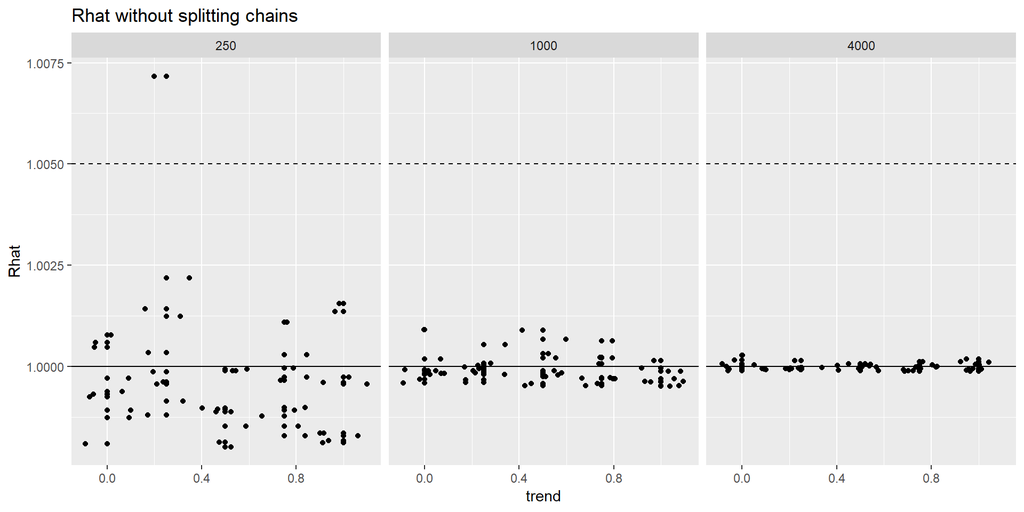

```r
ggplot(data=res, aes(y=Rhat, x=trend)) +
  geom_point() +
  geom_jitter() +
  facet_grid(. ~ iters) +
  geom_hline(yintercept = 1.005, linetype = 'dashed') +
  geom_hline(yintercept = 1) +
  ggtitle('Rhat without splitting chains')
```

Split-Rhat can detect trends, even if the marginals of the chains are similar.

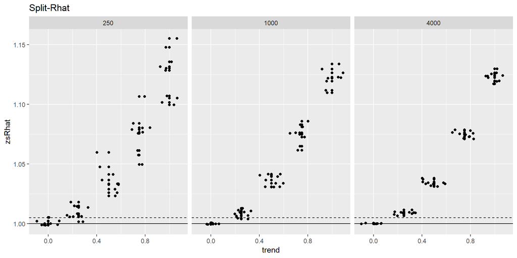

```r
ggplot(data=res, aes(y=zsRhat, x=trend)) +
  geom_point() + geom_jitter() +
  facet_grid(. ~ iters) +
  geom_hline(yintercept = 1.005, linetype = 'dashed') +
  geom_hline(yintercept = 1) +
  ggtitle('Split-Rhat')
```

**Result:** Split-Rhat is useful for detecting non-stationarity in the chains. If we use a threshold of $1.01$, we can detect trends which have acount for 2% of the total marginal variance. If we use a threshold of $1.1$, we can detect trends which acount for 30% of the total marginal variance.

Relative efficiency (effective sample size divided by the number of draws) is based on split Rhat and within-chain autocorrelation.

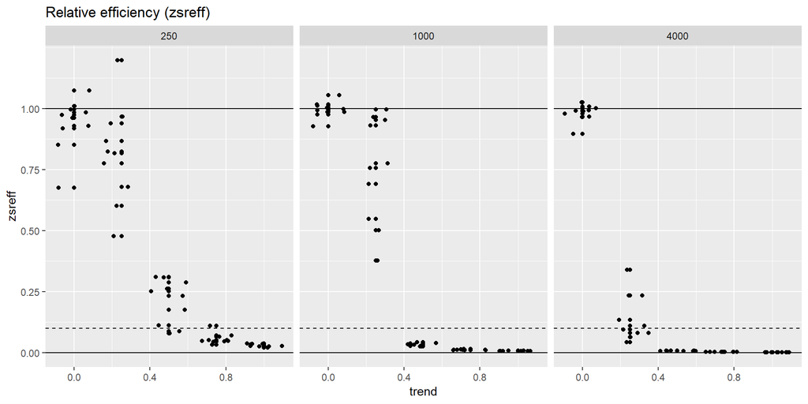

```r
ggplot(data=res, aes(y=zsreff, x=trend)) +
  geom_point() +
  geom_jitter() +
  facet_grid(. ~ iters) +
  geom_hline(yintercept = c(0,1)) +
  geom_hline(yintercept = 0.1, linetype = 'dashed') +
  ggtitle('Relative efficiency (zsreff)') +
  scale_y_continuous(breaks = seq(0,1,by=0.25))
```

**Result:** Split-Rhat is more sensitive to trends in small sample sizes, but relative efficiency is more sensitive with larger samples sizes (as autocorrelations can be estimated more accurately).

**Advice:** If in doubt, run longer chains for more accurate estimates.

### 4.2.2 Shifted: Three chains from $N(0,1)$ and one chain from $N(a,1)$

Next we investigate the sensitivity to detect if one of the chains has not converged to the same distribution as the others, but has a different mean.

```r
conds <- expand.grid(
  iters = c(250, 1000, 4000),
  shift = c(0, 0.25, 0.5, 0.75, 1),
  rep = 1:10
)
res <- vector("list", nrow(conds))
chains = 4
for (i in 1:nrow(conds)) {
  iters <- conds[i, "iters"]
  shift <- conds[i, "shift"]
  rep <- conds[i, "rep"]
  r <- array(rnorm(iters * chains), c(iters, chains))
  r[, 1] <- r[, 1] + shift
  rs <- monitor_simple(r)
  res[[i]] <- cbind(iters, shift, rep, rs)
}
res <- bind_rows(res)
```

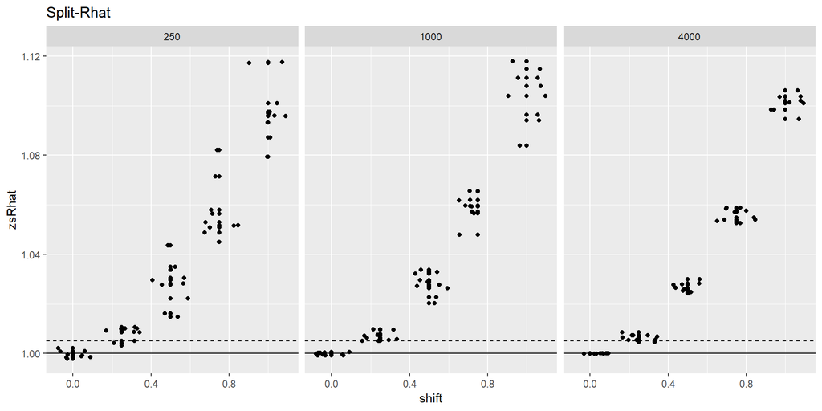

```r
ggplot(data=res, aes(y=zsRhat, x=shift)) +
  geom_point() +
  geom_jitter() +
  facet_grid(. ~ iters) +
  geom_hline(yintercept = 1.005, linetype = 'dashed') +
  geom_hline(yintercept = 1) +
  ggtitle('Split-Rhat')
```

**Result:** If we use a threshold of $1.01$, we can detect shift with a magnitude of one third of the marginal standard deviation. If we use a threshold of $1.1$, we can detect shift with a magnitude equal to the marginal standard deviation. The rank plot can be used to visualize where the problem is.

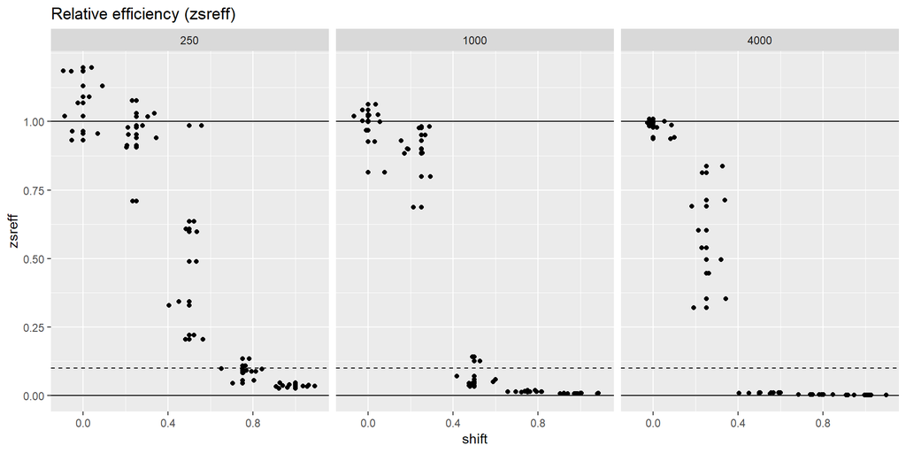

```r
ggplot(data=res, aes(y=zsreff, x=shift)) +
  geom_point() +
  geom_jitter() +
  facet_grid(. ~ iters) +
  geom_hline(yintercept = c(0,1)) +
  geom_hline(yintercept = 0.1, linetype = 'dashed') +
  ggtitle('Relative efficiency (zsreff)') +
  scale_y_continuous(breaks = seq(0,1,by=0.25))
```

**Result:** The relative efficiency is not as sensitive, but a shift with a magnitude of half the marginal standard deviation will lead to very low efficiency when sample size increases.

Rank plot visualisation for a case with 4 chains and 250 draws per chain, and shift = 0.5.

```r
iters = 250
chains = 4
shift = 0.5
r <- array(rnorm(iters * chains), c(iters, chains))
r[,1] <- r[,1] + shift
colnames(r) <- 1:4
```

```r
mcmc_hist_r_scale <- function(x, nbreaks = 50) {
  max <- prod(dim(x)[1:2])
  mcmc_hist(
    r_scale(x),
    breaks = seq(0, max, by = max / nbreaks) + 0.5
  )
}
```

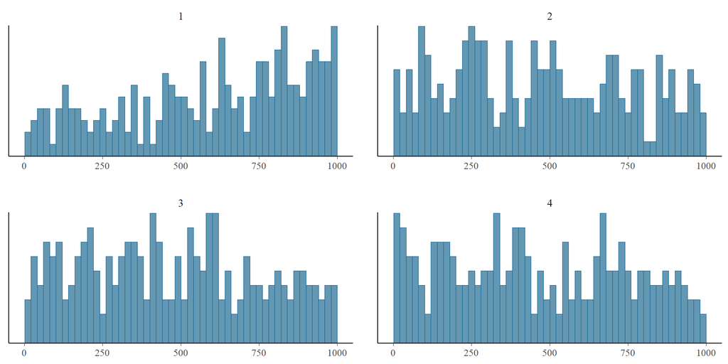

```r
mcmc_hist_r_scale(r)
```

Rhat is less than $1.05$, but the rank plot clearly shows the location of the problem (first chain).

### 4.2.3 Scaled: Three chains from $N(0,1)$ and one chain from $N(0,a)$

Next we investigate the sensitivity to detect if one of the chains has not converged to the same distribution as the others but has lower marginal variance.

```r
conds <- expand.grid(
  iters = c(250, 1000, 4000),
  scale = c(0, 0.25, 0.5, 0.75, 1),
  rep = 1:10
)
res <- vector("list", nrow(conds))
chains = 4
for (i in 1:nrow(conds)) {
  iters <- conds[i, "iters"]
  scale <- conds[i, "scale"]
  rep <- conds[i, "rep"]
  r <- array(rnorm(iters * chains), c(iters, chains))
  r[, 1] <- r[, 1] * scale
  rs <- monitor_simple(r)
  res[[i]] <- cbind(iters, scale, rep, rs)
}
res <- bind_rows(res)
```

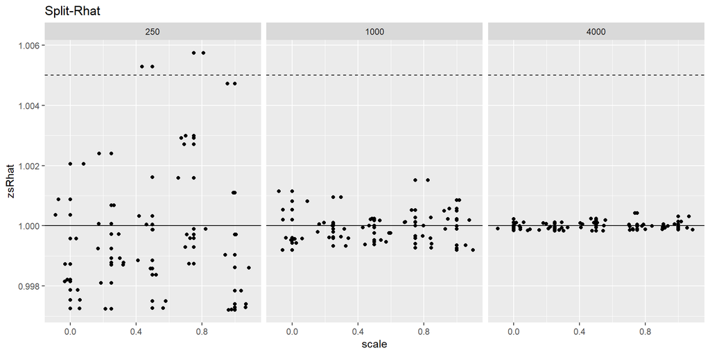

```r
ggplot(data=res, aes(y=zsRhat, x=scale)) +
  geom_point() +
  geom_jitter() +
  facet_grid(. ~ iters) +
  geom_hline(yintercept = 1.005, linetype = 'dashed') +
  geom_hline(yintercept = 1) +
  ggtitle('Split-Rhat')
```

**Result:** Split-Rhat is not able to detect scale differences between chains.

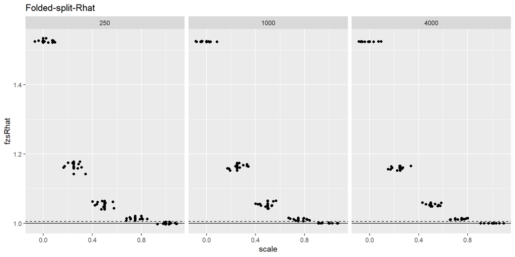

```r
ggplot(data=res, aes(y=fzsRhat, x=scale)) +
  geom_point() +
  geom_jitter() +
  facet_grid(. ~ iters) +
  geom_hline(yintercept = 1.005, linetype = 'dashed') +
  geom_hline(yintercept = 1) +
  ggtitle('Folded-split-Rhat')
```

**Result:** Folded-Split-Rhat focuses explicitely on scales and can thus detect scale differences.

**Result:** If we use a threshold of $1.01$, we can detect a chain with scale less than $3/4$ of the standard deviation of the others. If we use threshold of $1.1$, we can detect a chain with standard deviation less than $1/4$ of the standard deviation of the others.

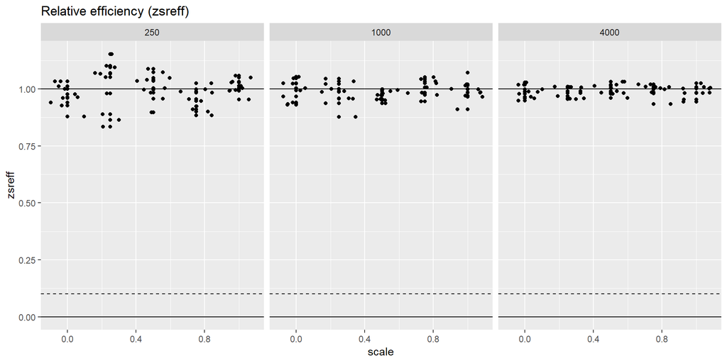

```r
ggplot(data=res, aes(y=zsreff, x=scale)) +
  geom_point() +
  geom_jitter() +
  facet_grid(. ~ iters) +
  geom_hline(yintercept = c(0,1)) +
  geom_hline(yintercept = 0.1, linetype = 'dashed') +
  ggtitle('Relative efficiency (zsreff)') +
  scale_y_continuous(breaks = seq(0,1,by=0.25))
```

**Result:** The relative efficiency does not see a problem as it focuses on location differences between chains.

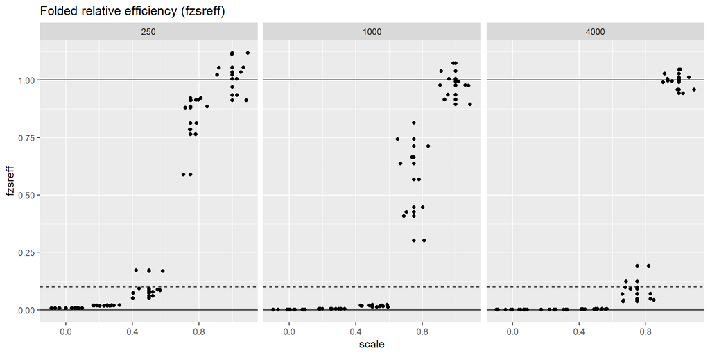

```r
ggplot(data=res, aes(y=fzsreff, x=scale)) +
  geom_point() +
  geom_jitter() +
  facet_grid(. ~ iters) +
  geom_hline(yintercept = c(0,1)) +
  geom_hline(yintercept = 0.1, linetype = 'dashed') +
  ggtitle('Folded relative efficiency (fzsreff)') +
  scale_y_continuous(breaks = seq(0,1,by=0.25))
```

**Result:** The relative efficiency of the standard deviation does see the problem as it focuses on scale.

Rank plot visualisation for a case with 4 chains and 250 draws per chain, and with one chain having a standard deviation of 0.75 as opposed to a standard deviation of 1 for the other chains.

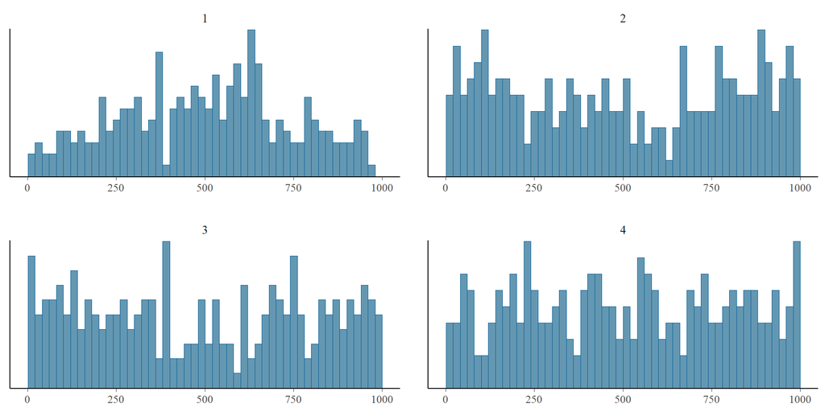

```r
iters = 250
chains = 4
scale = 0.75
r <- array(rnorm(iters * chains), c(iters, chains))
r[, 1] <- r[, 1] * scale
colnames(r) <- 1:4
mcmc_hist_r_scale(r)
```

## 4.3 Cauchy: A distribution with infinite mean and variance

The classic Rhat is based on calculating within and between chain variances. If the marginal distribution of a chain is such that the variance is not defined (i.e. infinite), the classic Rhat is not well justified. In this section, we will use the Cauchy distribution as an example of such distribution. Also in cases where mean and variance are finite, the distribution can be far from Gaussian. Especially distributions with very long tails cause instability for variance and autocorrelation estimates. To alleviate these problems we will use Split-Rhat for rank-normalized draws. Ranks are computed by using average for ties, as this is a deterministic procedure and constant chains are mapped to constant chains.

The following Cauchy models are from Michael Betancourt’s case study [Fitting The Cauchy Distribution](https://betanalpha.github.io/assets/case_studies/fitting_the_cauchy.html)

### 4.3.1 Nominal parameterization of Cauchy

The nominal cauchy model with direct parameterization is as follows.

```r
writeLines(readLines("cauchy_nom.stan"))
```

```
parameters {
  vector[50] x;
}

model {
  x ~ cauchy(0, 1);
}

generated quantities {
  real I = fabs(x[1]) < 1 ? 1 : 0;
}
```

#### 4.3.1.1 Default Stan options

Run the nominal model:

```r
fit_nom <- stan(file='cauchy_nom.stan', seed=7878, refresh = 0)
```

```
Warning: There were 1233 transitions after warmup that exceeded the maximum treedepth. Increase max_treedepth above 10. See
http://mc-stan.org/misc/warnings.html#maximum-treedepth-exceeded
```

```
Warning: There were 4 chains where the estimated Bayesian Fraction of Missing Information was low. See
http://mc-stan.org/misc/warnings.html#bfmi-low
```

```
Warning: Examine the pairs() plot to diagnose sampling problems
```

The diagnostics warn about very large number of transitions after warmup that exceeded the maximum treedepth, which is likely due to very long tails of the Cauchy distribution. All chains have low estimated Bayesian fraction of missing information also indicating slow mixing.

MCMC trace for the first parameter looks wild with occasional large values

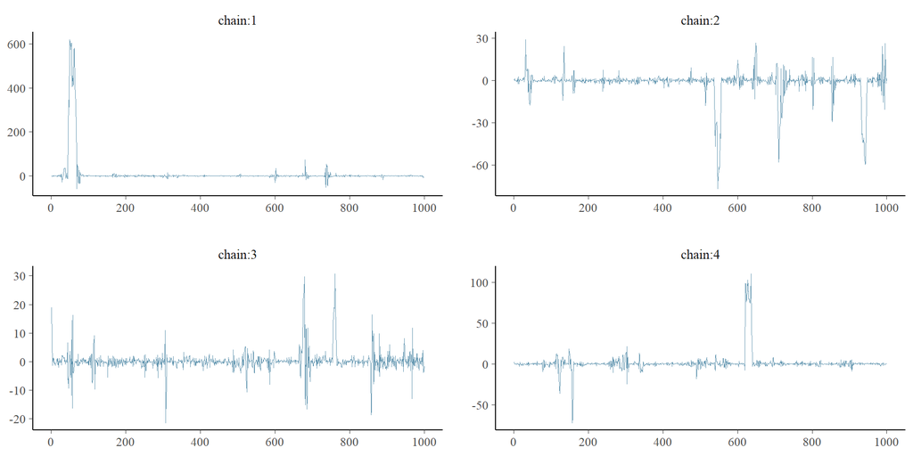

```r
samp <- as.array(fit_nom)
mcmc_trace(samp[, , 1])
```

Let’s check Rhat and relative efficiency diagnostics.

```r
res <- monitor_simple(samp[, , 1:50])
which_min_eff <- which(res$zsreff == min(res$zsreff))
```

```r
plot_rhat <- function(res) {
  p1 <- ggplot(res, aes(x=par, y=sRhat)) +
    geom_point() +
    ggtitle('Classic Split-Rhat') +
    geom_hline(yintercept = 1.005, linetype = 'dashed') +
    geom_hline(yintercept = 1) +
    ylim(c(.99 ,1.26))

  p2 <- ggplot(res, aes(x=par, y=zsRhat)) +
    geom_point() +
    ggtitle('Rank normalized split-Rhat') +
    geom_hline(yintercept = 1.005, linetype = 'dashed') +
    geom_hline(yintercept = 1) +
    ylim(c(.99,1.26))

  p3 <- ggplot(res, aes(x=par, y=fzsRhat)) +
    geom_point() +
    ggtitle('Folded rank split-Rhat') +
    geom_hline(yintercept = 1.005, linetype = 'dashed') +
    geom_hline(yintercept = 1) +
    ylim(c(.99,1.26))

  grid.arrange(p1, p2, p3, nrow = 1)
}
```

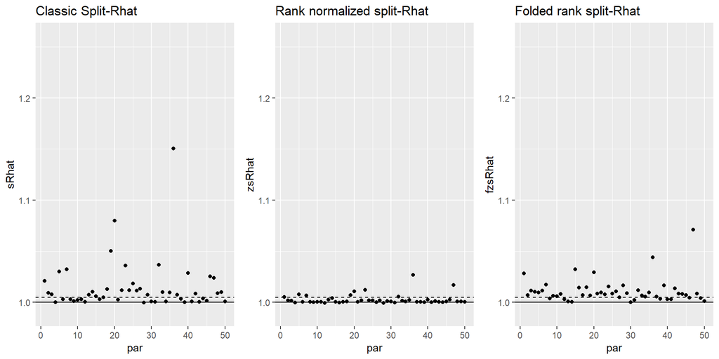

```r
plot_rhat(res)
```

For one parameter, Rhats exceed the classic threshold of 1.1. Depending on the Rhat estimate, a few others also exceed the threshold 1.01. The rank normalized split-Rhat have several values over 1.01. Please note that the classic Rhat is not well defined in this example.

```r
plot_reff <- function(res) {
  ymax <- 2
  ybreaks <- seq(0, ymax, by = 0.25)
  ylimits <- c(0, ymax)

  p1 <- ggplot(res, aes(x=par, y=reff)) +
    geom_point() +
    ggtitle('Classic rel. efficiency (reff)') +
    geom_hline(yintercept = c(0,1)) +
    geom_hline(yintercept = 0.1, linetype = 'dashed') +
    scale_y_continuous(breaks = ybreaks, limits = ylimits)

  p2 <- ggplot(res, aes(x=par, y=zsreff)) +
    geom_point() +
    ggtitle('New rel. efficiency (zsreff)') +
    geom_hline(yintercept = c(0,1)) +
    geom_hline(yintercept = 0.1, linetype = 'dashed') +
    scale_y_continuous(breaks = ybreaks, limits = ylimits)

  p3 <- ggplot(res, aes(x=par, y=fzsreff)) +
    geom_point() +
    ggtitle('Folded rel. efficiency (fzsreff)') +
    geom_hline(yintercept = c(0,1)) +
    geom_hline(yintercept = 0.1, linetype = 'dashed') +
    scale_y_continuous(breaks = ybreaks, limits = ylimits)

  p4 <- ggplot(res, aes(x=par, y=medsreff)) +
    geom_point() +
    ggtitle('Rel.eff. of median (medsreff)') +
    geom_hline(yintercept = c(0,1)) +
    geom_hline(yintercept = 0.1, linetype = 'dashed') +
    scale_y_continuous(breaks = ybreaks, limits = ylimits)

  p5 <- ggplot(res, aes(x=1:50, y=madsreff)) +
    geom_point() +
    ggtitle('Rel.eff. of mad (madsreff)') +
    geom_hline(yintercept = c(0,1)) +
    geom_hline(yintercept = 0.1, linetype = 'dashed') +
    scale_y_continuous(breaks = ybreaks, limits = ylimits)

  blank <- grid::grid.rect(gp = grid::gpar(col="white"), draw = FALSE)
  grid.arrange(p1, p2, p3, blank, p4, p5, nrow = 2)
}
```

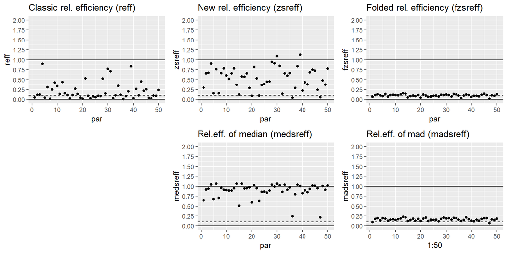

```r
plot_reff(res)
```

Both classic and rank normalized relative efficiency estimates have several near zero values, and the overall samples shouldn’t be trusted.

**Result:** Relative efficiency is more sensitive than (rank-normalized) split-Rhat to detect problems of slow mixing.

We also check the indicator function `I` and `lp__` and find out that the relative efficiency for `lp__` is worryingly low.

```r
res <- monitor_simple(samp[, , 51:52])
cat('I: r_eff = ', round(res['I','zsreff'], 2), '\n')
```

```
I: r_eff =  0.1
```

```r
cat('lp__: r_eff = ', round(res['lp__','zsreff'], 2), '\n')
```

```
lp__: r_eff =  0.03
```

Next, we examine the relative efficiency in different parts of the posterior by computing the relative efficiency for $p(\hat{Q}_\alpha \le x < \hat{Q}_{\alpha+0.05})$, where $\hat{Q}_\alpha$ is the empirical $\alpha$-quantile and $\alpha \in (0,0.05,\ldots,0.95)$ varies in steps of $5%$. Each interval contains $5%$ of the draws and the efficiency measures autocorrelation of an indicator function which indicates when the values are inside the specific interval. This gives us a local efficiency measure which is does not depend on the shape of the distribution.

```r
plot_local_reff <- function(samp = NULL, par = NULL, nalpha = NULL) {
  delta <- 1 / nalpha
  alphas <- seq(0, 1 - delta, by = delta)
  zsreffs <- rep(NA, length(alphas))
  for (i in seq_along(alphas)) {
    alpha <- alphas[i]
    tmp <- samp[, , par]
    I <- tmp >= quantile(tmp, alpha) & tmp < quantile(tmp, alpha + delta)
    rs <- monitor_simple(I)
    zsreffs[i] <- rs$zsreff[1]
  }
  df <- data.frame(
    quantile = seq(0, 1, by = delta),
    zsreff = c(zsreffs, zsreffs[nalpha])
  )
  ggplot(data=df, aes(x=quantile, y=zsreff)) +
    geom_step() +
    geom_hline(yintercept = c(0,1)) +
    geom_hline(yintercept = 0.1, linetype = 'dashed') +
    scale_x_continuous(breaks = seq(0,1, by=0.1)) +
    scale_y_continuous(
      breaks = seq(0, 1, by=0.25),
      limits = c(0, 1.1)
    )
}
```

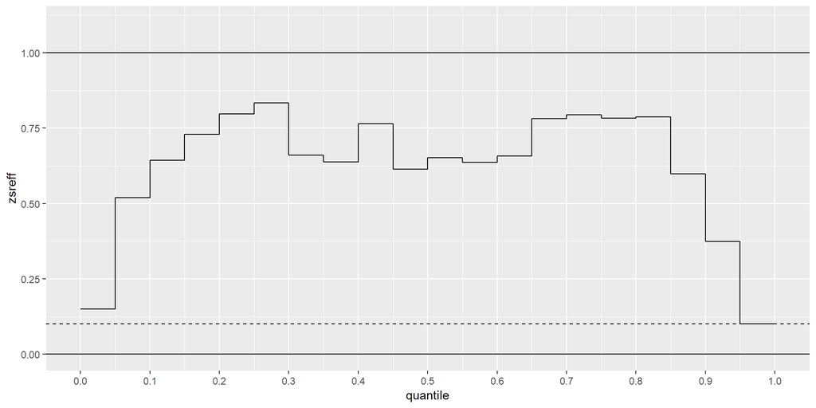

```r
plot_local_reff(samp = samp, par = 1, nalpha = 20)
```

We see that MCMC is less efficient in the tails.

Alternative way to examine the relative efficiency in different parts of the posterior, is to compute relative efficiency for $p(x < \hat{Q}_{\alpha})$, where $\hat{Q}_\alpha$ is the empirical $\alpha$-quantile and $\alpha \in (0.025,\ldots,0.975)$. This is related to the efficiency of quantile estimates. Each interval has specified proportion of draws, and the efficiency measures autocorrelation of an indicator function which indicates when the values are inside the specific interval. This gives us a local efficiency measure which is indepedent on the shape of the distribution.

```r
plot_quantile_reff <- function(samp = NULL, par = NULL, nalpha=NULL) {
  delta <- 1 / nalpha
  alphas <- seq(delta, 1 - delta, by = delta)
  zsreffs <- rep(NA, length(alphas))
  for (i in seq_along(alphas)) {
    alpha <- alphas[i]
    tmp <- samp[, , par]
    I <- tmp < quantile(tmp, alpha)
    rs <- monitor_simple(I)
    zsreffs[i] <- rs$zsreff[1]
  }
  df <- data.frame(
    quantile = seq(delta, 1 - delta, by = delta),
    zsreff = zsreffs
  )
  ymax <- max(1, round(max(zsreffs, na.rm = TRUE) + 0.15, 1))
  ggplot(df, aes(x=quantile, y=zsreff)) +
    geom_point() +
    geom_hline(yintercept = c(0,1)) +
    geom_hline(yintercept = 0.1, linetype = 'dashed') +
    scale_x_continuous(breaks = seq(0,1, by=0.1)) +
    scale_y_continuous(
      breaks = seq(0, ymax, by = 0.25),
      limits = c(0, ymax)
    )
}
```

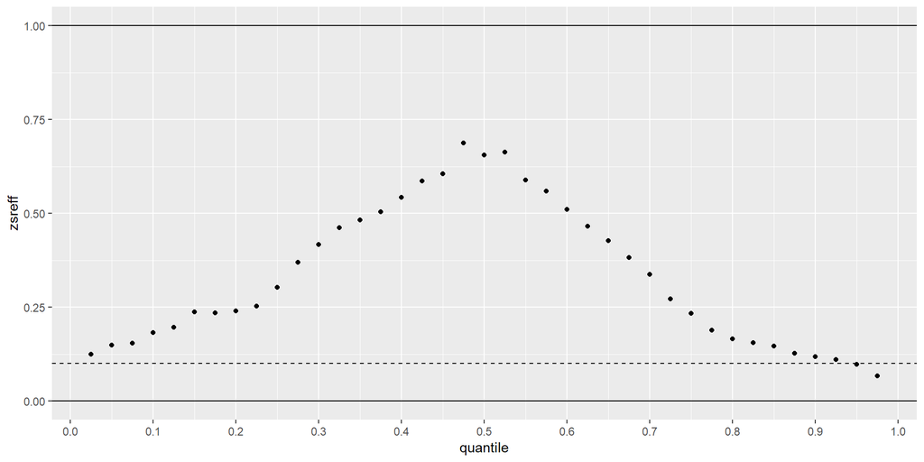

```r
plot_quantile_reff(samp = samp, par = 1, nalpha = 40)
```

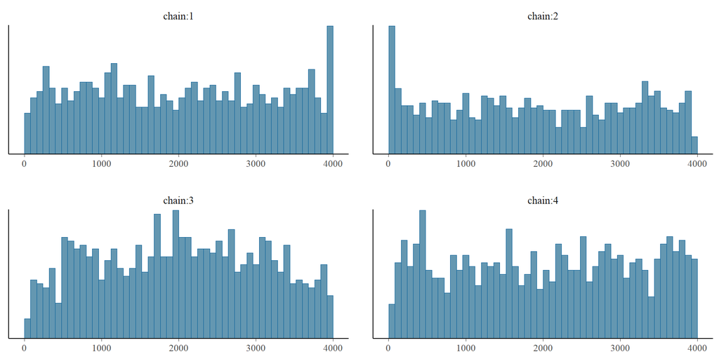

```r
mcmc_hist_r_scale(samp[, , 1])
```

The chains clearly have different rank plots.

The rank plot visualisation of x[36], which has a relative efficiency of 0.03, also indicates clear problems with mixing.

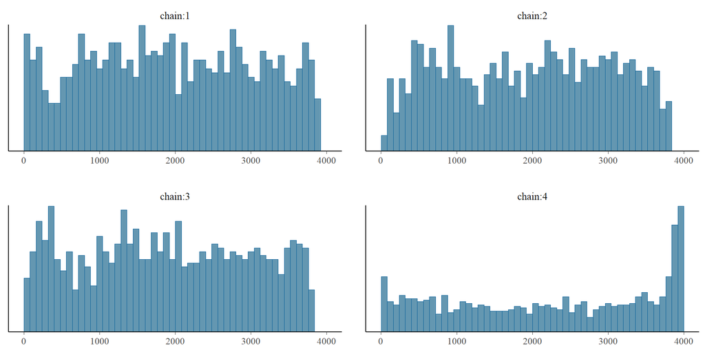

```r
xmin <- paste0("x[", which_min_eff, "]")
mcmc_hist_r_scale(samp[, , xmin])
```

#### 4.3.1.2 Default Stan options + `max_treedepth=20`

We can try to improve the performance by increasing `max_treedepth`.

```r
fit_nom_td20 <- stan(
  file='cauchy_nom.stan', seed=7878,
  refresh = 0, control = list(max_treedepth=20)
)
```

MCMC trace for the first parameter looks wild with occasional large values.

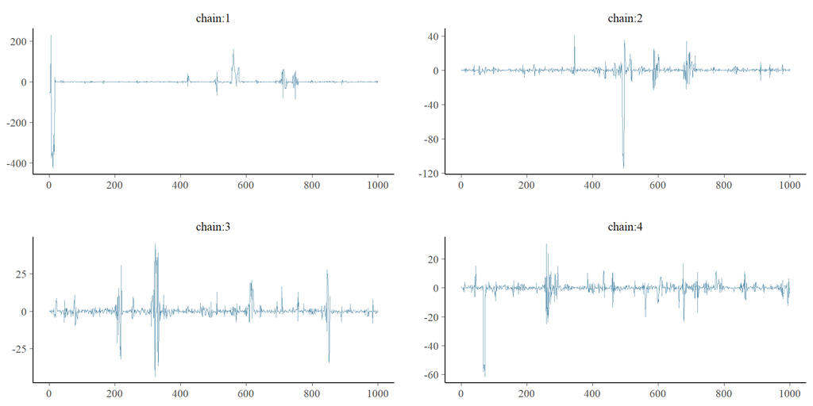

```r
samp <- as.array(fit_nom_td20)
mcmc_trace(samp[, , 1])
```

```r
res <- monitor_simple(samp[, , 1:50])
which_min_eff <- which(res$zsreff == min(res$zsreff))
```

Treedepth exceedence and Bayesian Fraction of Missing Information are HMC/NUTS specific diagnostics. Let’s see what generic Split-Rhat and relative efficiency can detect.

We check the diagnostics for all x’s.

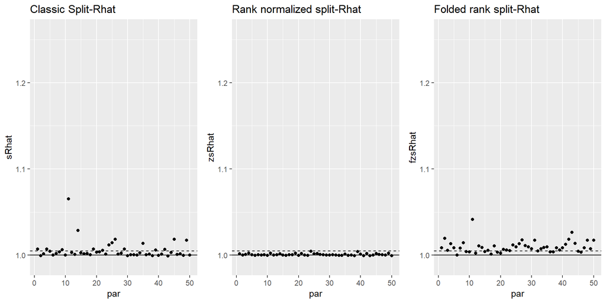

```r
plot_rhat(res)
```

All Rhats are below $1.1$, but many are over $1.01$. Classic Rhat has more variation than the rank normalized (and the former is not well defined). The folded rank normalized Rhat shows that there is still more variation in scale than location between different chains.

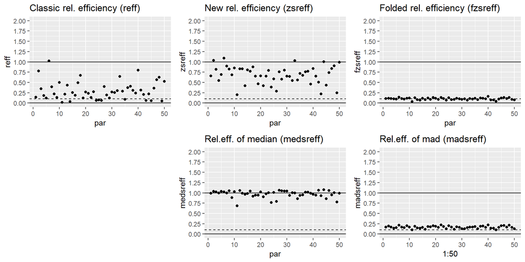

```r
plot_reff(res)
```

Some classic relative efficiencies (reffs) are close to zero. If we wouldn’t realize that the variance is infinite, we might try to run longer chains, but in case of infinite variance, zero efficiency is the truth and longer chains won’t help. However other quantities can be well defined, and that’s why it is useful also to look at the rank normalized version as a generic transformation with finite mean and variance. The smallest rank-normalized r_eff are around $0.25$, which is not that bad. There is still large variation between parameters although they all have the same distribution.

**Result:** Rank normalized relative efficiency is more stable than classic relative efficiency, which is not well defined for Cauchy.

```r
res <- monitor_simple(samp[, , 51:52])
cat('I: r_eff = ', round(res['I','zsreff'],2), '\n')
```

```
I: r_eff =  0.17
```

```r
cat('lp__: r_eff = ', round(res['lp__','zsreff'],2), '\n')
```

```
lp__: r_eff =  0.06
```

We examine the relative efficiency in different parts of the posterior, by computing the relative efficiency for $p(\hat{Q}_\alpha \le x < \hat{Q}_{\alpha+0.05})$, where $\hat{Q}_\alpha$ is $\alpha$-quantile and $\alpha \in (0,0.05,\ldots,0.95)$.

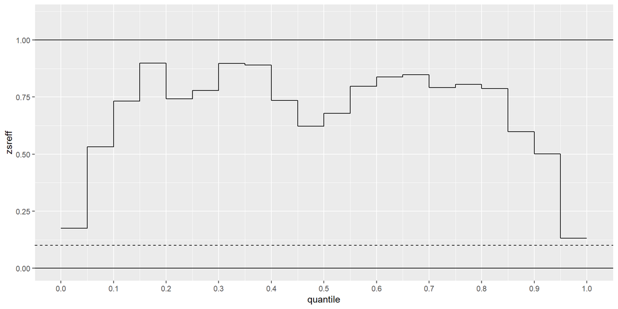

```r
plot_local_reff(samp = samp, par = 1, nalpha = 20)
```

Increasing `max_treedepth` improved the efficiency slightly in the tails.

We examine the relative efficiency in different parts of the posterior, by computing the relative efficiency for $p(x < \hat{Q}_{\alpha})$, where $\hat{Q}_\alpha$ is $\alpha$-quantile and $\alpha \in (0,0.025,\ldots,0.975)$ in steps of $0.025$.

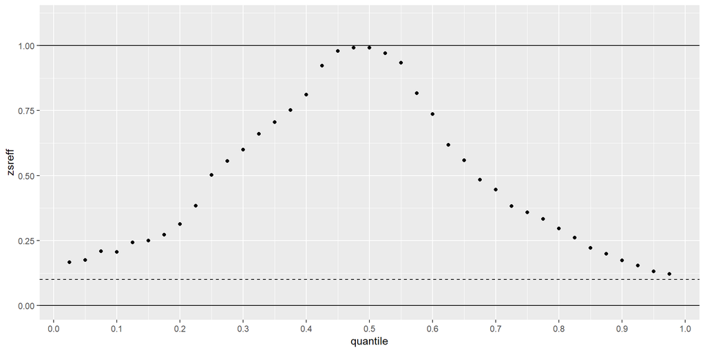

```r
plot_quantile_reff(samp = samp, par = 1, nalpha = 40)
```

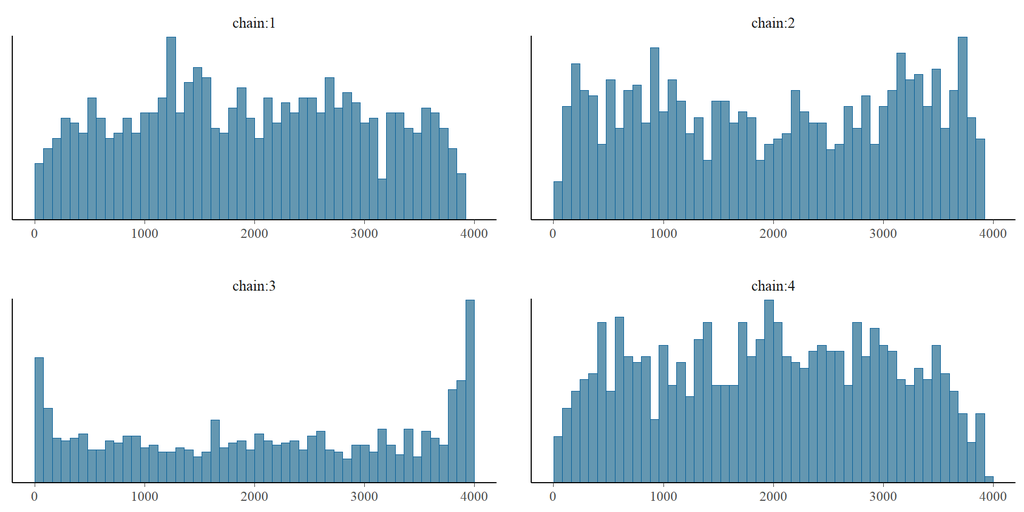

```r
xmin <- paste0("x[", which_min_eff, "]")
mcmc_hist_r_scale(samp[, , xmin])
```

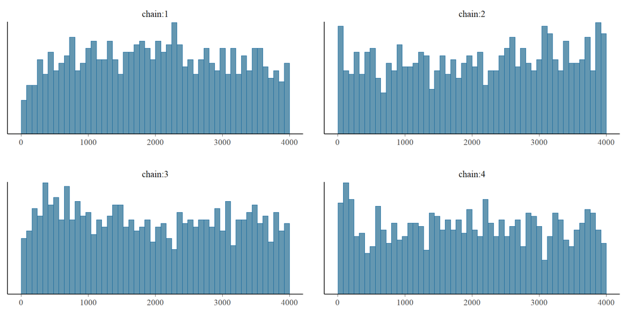

```r
mcmc_hist_r_scale(samp[, , "lp__"])
```

#### 4.3.1.3 Default Stan options + `max_treedepth = 20` + 8 times longer sampling

Let’s try running longer chains.

```r
fit_nom_td20l <- stan(
  file='cauchy_nom.stan', seed=7878,
  refresh = 0, control = list(max_treedepth=20),
  warmup=1000, iter = 9000
)
```

MCMC trace for the first parameter looks wild with occasional large values

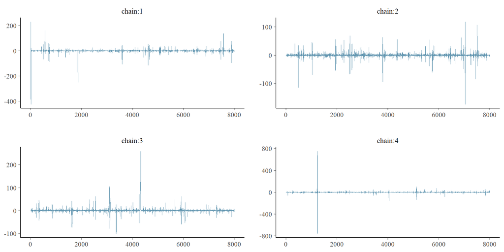

```r
samp <- as.array(fit_nom_td20l)
mcmc_trace(samp[, , 1])
```

```r
res <- monitor_simple(samp[, , 1:50])
which_min_eff <- which(res$zsreff == min(res$zsreff))
```

Treedepth exceedence and Bayesian Fraction of Missing Information are HMC/NUTS specific diagnostics. Let’s see what generic Split-Rhat and relative efficiency can detect. Check the diagnostics for all x’s.

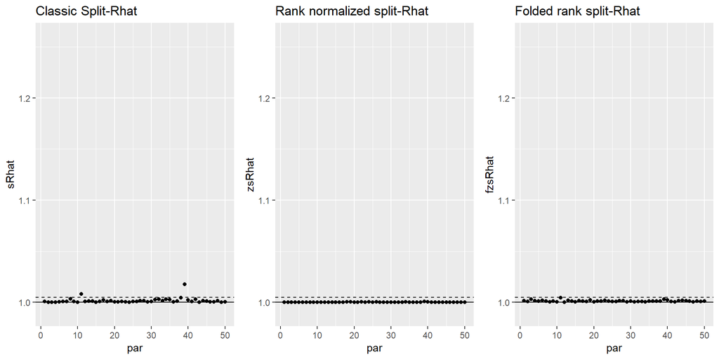

```r
plot_rhat(res)
```

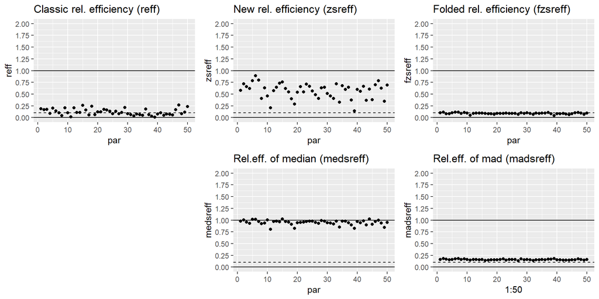

```r
plot_reff(res)
```

Most classic relative efficiencies (reffs) are close to zero. If we wouldn’t realize that the variance is infinite, we might try to run longer chains, but in case of infinite variance zero is the true value and longer chains don’t help. However other quantities can be well defined, and that’s why it can be useful also to look at the rank normalized version as a generic transformation with finite mean and variance. The rank-normalized r_eff’s start to concentrate around 0.6, which is quite good. There is still some variation between parameters.

**Result:** Rank normalized relative efficiency is more stable than classic relative efficiency, which is not well defined for Cauchy.